# 4. Options

Investigate the mechanics and use of S&P 500 options to hedge Perishing Square's portfolio.

For the purposes of this assignment, the put options prices as outlined in Exhibit 4 of Pershing Square’s Pandemic Trade (A) will be used for any quantitative analysis. A literature review and coding examples have been provided as part of this analysis.

### Key Assumptions And Limitations

- The evaluation date (i.e. the date in which Pershing Square must make a decision on their Hedging strategy) is February 21, 2020
- Limited by the data we were able to find.

**Table of Contents**

```python
pip install scipy
```

[output not shown]

**Libraries**

```python
import yfinance as yf
import pandas as pd
from datetime import datetime
import matplotlib.pyplot as plt
import numpy as np
from scipy.stats import norm
import matplotlib.ticker as ticker
import matplotlib.dates as mdates
```

## 4.1 Hedging Position and Key Details

To protect *Pershing Square's* portfolio from adverse market movements, Bill Ackman could utilise *purchasing* S&P 500 index put options as a hedging instrument.

### Literature review

A put option gives the holder the right, but not the obligation, to sell the underlying asset (in this case, the S&P 500 index) at a predetermined price (the strike price) on or before the expiration date. This allows the holder to benefit if the price of the underlying asset falls below the strike price.

Put Option Payoff The payoff of a put option at expiration depends on the relationship between the price of the underlying asset $(S_T)$ and the strike price $(K)$. If the underlying asset price is below the strike price, the payoff is positive. Otherwise, the option expires worthless. The payoff of a put option is given by:

$$\text{Put Option Payoff} = \max (K - S_T , 0)$$

Where:

- $(S_T)$ is the price of the S&P 500 index at expiration.
- $K$ is the strike price of the put option.

### Determining the Optimal Number of Contracts

The optimal number of contracts $h$ can be calculated using the following formula:

$$h = \frac{\beta V}{F} = \bar{\rho} \frac{\bar{\sigma}_{A}V }{\bar{\sigma}_KF}$$

Where:

- $h$ is the number of futures contracts to purchase or sell.
- $\beta$ is the beta of the portfolio relative to the S&P 500 (this measures the portfolio's sensitivity to market movements).
- $V$ is the value of the portfolio being hedged.
- $F$ is the notional value of one futures contract on the S&P 500 index, calculated as the index value multiplied by the contract multiplier.
- $\sigma _{A_t}$ is the standard deviation (volatility) in $A_t − A$.
- $\sigma _{K_t}$ is the standard deviation (volatility) in $K_t − K$.
- $\rho$ is the correlation between $A_t − A$ and $K_t − K$.

### Contract Choice

In regards to the choice on options contract, the closest to 'At The Money' (ATM) option with a strike price of 3300 was chosen.

```python
# general key info
EVAL_DATE = '2020-02-21'
EVAL_DATE_PLUS_ONE = '2020-02-22'

THIRTY_DAY_SOFR = 0.00154

# Historic price excel doc
HISTORIC_PRICE_EXCEL = 'portfolio_values_eval_date.xlsx'
HISTORIC_PRICE_EXCEL_SHEET_NAME = 'Values'

# Contract info
EXPIRY_MAR = '2020-03-20'
EXPIRY_MAR_PLUS_ONE = '2020-03-21'

EXPIRY_APR = '2020-04-17'
EXPIRY_APR_PLUS_ONE = '2020-04-18'

P_MAR = 52.80  # Using Ask Price
P_APR = 67.90  # Using Ask Price

T_MAR = (datetime.strptime(EXPIRY_MAR, '%Y-%m-%d') - datetime.strptime(EVAL_DATE, '%Y-%m-%d')).days / 360
T_APR = (datetime.strptime(EXPIRY_APR, '%Y-%m-%d') - datetime.strptime(EVAL_DATE, '%Y-%m-%d')).days / 360

K = 3300 # At the money put option

OPT_CONTRACT_SIZE = 50

# hedging info from previous section
BETA_SPX_P = 0.592918
FIRM_VALUE = 7_621.28 * 1_000_000


### Price of the S&P 500 index on the 21st Feb:
spx_price = yf.download("^SPX", start=EVAL_DATE, end=EVAL_DATE_PLUS_ONE)["Adj Close"].loc[EVAL_DATE]

# Hedge Pershing Square's portfolio using PUT options with key figures as above:

F = K * OPT_CONTRACT_SIZE

H = BETA_SPX_P * FIRM_VALUE / F
```

```
[*********************100%***********************]  1 of 1 completed
```

#### 4.1.1 Option Costs

```python
# March expiry
cost_mar_expiry = H * P_MAR
cost_apr_expiry = H * P_APR

stats = f'''
############ KEY STATISTICS ############
Beta: {BETA_SPX_P:6f}
Optimal number of contracts to hedge firm position: {int(round(H, 0))}
(unrounded {H:2f})

Face value of futures contract on evaluation date ({EVAL_DATE}): ${F:2f}'


############ UPFRONT COSTS ############
Cost for put options, March ({EXPIRY_MAR}) expiry: ${cost_mar_expiry:.2f}
Cost for put options, April ({EXPIRY_APR}) expiry: ${cost_apr_expiry:.2f}
'''

print(stats)
```

```
############ KEY STATISTICS ############
Beta: 0.592918
Optimal number of contracts to hedge firm position: 27387
(unrounded 27386.630879)

Face value of futures contract on evaluation date (2020-02-21): $165000.000000'


############ UPFRONT COSTS ############
Cost for put options, March (2020-03-20) expiry: $1446014.11
Cost for put options, April (2020-04-17) expiry: $1859552.24
```

## 4.2 Timing in the Market

Following the discussion above, we assume the the optimal timing to exit the market is at the maximum payoff of exercising the put options contract. For European options, the holder can choose to exercise at maturity $T$ and no time $t <= T$. It would be illogical to graphically illustrate a payoff diagram between the evaluation date $T_0$ and $T$ since the holder (Pershing Square) would be unable to exercise it.

$$\text{Payoff} = e^{-rT}(K - S_T)$$

```python
spx_price_mar_exp = yf.download("^SPX", start=EXPIRY_MAR, end=EXPIRY_MAR_PLUS_ONE)["Adj Close"].loc[EXPIRY_MAR]
payoff_mar = max(0, K - spx_price_mar_exp) * (H * OPT_CONTRACT_SIZE) * np.exp(THIRTY_DAY_SOFR * T_MAR * -1)

spx_price_mar_apr = yf.download("^SPX", start=EXPIRY_APR, end=EXPIRY_APR_PLUS_ONE)["Adj Close"].loc[EXPIRY_APR]
payoff_apr = max(0, K - spx_price_mar_apr) * (H * OPT_CONTRACT_SIZE) * np.exp(THIRTY_DAY_SOFR * T_APR * -1)

print(f'Payoff of Options contract in March: ${payoff_mar:.4f}')
print(f'Payoff of Options contract in April: ${payoff_apr:.4f}')
```

```
[*********************100%***********************]  1 of 1 completed
[*********************100%***********************]  1 of 1 completed
```

```
Payoff of Options contract in March: $1362431340.9623
Payoff of Options contract in April: $582428791.0586
```

### Payoffs

In this analysis, we estimated the payoffs for put options with varying exercise prices (K) for two expiration dates: March and April. The payoffs were calculated using the formula:

$$ \text{Payoff} = \max(0, K - S) \left( \frac{\beta V}{KC} \right) C e^{-\text{r} T}$$

where $S$ is the underlying asset price, $\beta_{SPX}$ represents the sensitivity of the asset, $V_{firm}$ is the firm's value, $C$ is the options contract size, and $T$ is the time to expiration in years. The payoffs for all exercise prices were visualized using a scatter plot.

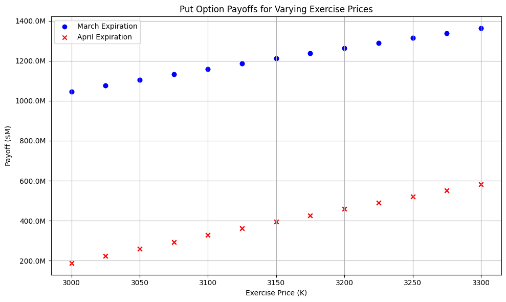

```python
file_path = 'options_data/put_option_prices.xlsx'
put_prices_df = pd.read_excel(file_path, sheet_name='prices')

# Extract exercise prices (K) and put option prices from the dataframe
K = put_prices_df['Exercise Price'].values  # Modify the column name as necessary
put_prices = put_prices_df['Ask Price'].values  # Modify the column name as necessary

# Calculate payoffs for varying exercise prices
payoffs_mar = np.maximum(0, K - spx_price_mar_exp) * (((BETA_SPX_P * FIRM_VALUE) /
    (K * OPT_CONTRACT_SIZE)) * OPT_CONTRACT_SIZE) * np.exp(THIRTY_DAY_SOFR * T_APR * -1)
payoffs_apr = np.maximum(0, K - spx_price_mar_apr) * (((BETA_SPX_P * FIRM_VALUE) /
    (K * OPT_CONTRACT_SIZE)) * OPT_CONTRACT_SIZE) * np.exp(THIRTY_DAY_SOFR * T_APR * -1)


plt.figure(figsize=(10, 6))
plt.scatter(K, payoffs_mar, label='March Expiration', color='blue', marker='o')
plt.scatter(K, payoffs_apr, label='April Expiration', color='red', marker='x')
plt.title('Put Option Payoffs for Varying Exercise Prices')
plt.xlabel('Exercise Price (K)')
plt.ylabel('Payoff ($M)')
plt.gca().yaxis.set_major_formatter(ticker.FuncFormatter(lambda x, pos: f'{x*1e-6:.1f}M'))
plt.legend()
plt.grid()
plt.tight_layout()
plt.show()
```

Consider that for Pershing Square, the combined change in value of their holdings if they chose to hedge with options contracts would be:

1. The value profit (or loss) of their holdings from evaluation date (`Feb 21 2020`)
2. The value of the options contracts at time $t$
3. Premium paid on options contracts at time $t_0$

```python
K = 3300

df = pd.read_excel(HISTORIC_PRICE_EXCEL, sheet_name=HISTORIC_PRICE_EXCEL_SHEET_NAME, index_col='Date')
df_profits = df[df.index >= EVAL_DATE].copy()

firm_value_eval_date = df_profits['Firm Value'].loc[EVAL_DATE]

df_profits = df_profits[['Firm Value', '^spx']]
df_profits['Firm Profit'] = df_profits['Firm Value'] - firm_value_eval_date
df_profits['Payoff March Option'] = np.where(
    df_profits.index < EXPIRY_MAR,
    np.maximum(0, K - df_profits['^spx']) * (((BETA_SPX_P * FIRM_VALUE) / (K * OPT_CONTRACT_SIZE)) * OPT_CONTRACT_SIZE),
    0)
df_profits['Payoff April Option'] = np.where(
    df_profits.index < EXPIRY_APR,
    np.maximum(0, K - df_profits['^spx']) * (((BETA_SPX_P * FIRM_VALUE) / (K * OPT_CONTRACT_SIZE)) * OPT_CONTRACT_SIZE),
    0)

df_profits['Payoff March Option'] = df_profits['Payoff March Option'].replace(0, np.nan).ffill()
df_profits['Payoff April Option'] = df_profits['Payoff April Option'].replace(0, np.nan).ffill()


df_profits['Value March'] = df_profits['Firm Value'] + df_profits['Payoff March Option'] - cost_mar_expiry
df_profits['Value April'] = df_profits['Firm Value'] + df_profits['Payoff April Option'] - cost_apr_expiry
df_profits.head(50)
```

| Date | Firm Value | ^spx | Firm Profit | Payoff March Option | Payoff April Option | Value March | Value April |
| --- | --- | --- | --- | --- | --- | --- | --- |
| 2020-02-21 | 7.697406e+09 | 3337.750000 | 0.000000e+00 | NaN | NaN | NaN | NaN |
| 2020-02-24 | 7.430339e+09 | 3225.889893 | -2.670668e+08 | 1.014813e+08 | 1.014813e+08 | 7.530375e+09 | 7.529961e+09 |
| 2020-02-25 | 7.146771e+09 | 3128.209961 | -5.506346e+08 | 2.352375e+08 | 2.352375e+08 | 7.380563e+09 | 7.380149e+09 |
| 2020-02-26 | 7.040026e+09 | 3116.389893 | -6.573798e+08 | 2.514231e+08 | 2.514231e+08 | 7.290003e+09 | 7.289590e+09 |
| 2020-02-27 | 6.685772e+09 | 2978.760010 | -1.011634e+09 | 4.398841e+08 | 4.398841e+08 | 7.124210e+09 | 7.123797e+09 |
| 2020-02-28 | 6.618340e+09 | 2954.219971 | -1.079066e+09 | 4.734875e+08 | 4.734875e+08 | 7.090382e+09 | 7.089968e+09 |
| 2020-03-02 | 6.814513e+09 | 3090.229980 | -8.828933e+08 | 2.872447e+08 | 2.872447e+08 | 7.100311e+09 | 7.099898e+09 |
| 2020-03-03 | 6.596649e+09 | 3003.370117 | -1.100757e+09 | 4.061847e+08 | 4.061847e+08 | 7.001387e+09 | 7.000974e+09 |
| 2020-03-04 | 6.845999e+09 | 3130.120117 | -8.514073e+08 | 2.326219e+08 | 2.326219e+08 | 7.077175e+09 | 7.076761e+09 |
| 2020-03-05 | 6.496462e+09 | 3023.939941 | -1.200944e+09 | 3.780177e+08 | 3.780177e+08 | 6.873034e+09 | 6.872621e+09 |
| 2020-03-06 | 6.396099e+09 | 2972.370117 | -1.301307e+09 | 4.486339e+08 | 4.486339e+08 | 6.843287e+09 | 6.842874e+09 |
| 2020-03-09 | 5.830281e+09 | 2746.560059 | -1.867125e+09 | 7.578428e+08 | 7.578428e+08 | 6.586678e+09 | 6.586265e+09 |
| 2020-03-10 | 6.124975e+09 | 2882.229980 | -1.572431e+09 | 5.720657e+08 | 5.720657e+08 | 6.695594e+09 | 6.695181e+09 |
| 2020-03-11 | 5.680923e+09 | 2741.379883 | -2.016483e+09 | 7.649361e+08 | 7.649361e+08 | 6.444413e+09 | 6.443999e+09 |
| 2020-03-12 | 5.148352e+09 | 2480.639893 | -2.549054e+09 | 1.121976e+09 | 1.121976e+09 | 6.268882e+09 | 6.268468e+09 |
| 2020-03-13 | 5.542638e+09 | 2711.020020 | -2.154768e+09 | 8.065089e+08 | 8.065089e+08 | 6.347701e+09 | 6.347288e+09 |
| 2020-03-16 | 4.755585e+09 | 2386.129883 | -2.941821e+09 | 1.251391e+09 | 1.251391e+09 | 6.005530e+09 | 6.005117e+09 |
| 2020-03-17 | 4.663500e+09 | 2529.189941 | -3.033906e+09 | 1.055495e+09 | 1.055495e+09 | 5.717549e+09 | 5.717135e+09 |
| 2020-03-18 | 4.176677e+09 | 2398.100098 | -3.520729e+09 | 1.235000e+09 | 1.235000e+09 | 5.410231e+09 | 5.409818e+09 |
| 2020-03-19 | 4.328365e+09 | 2409.389893 | -3.369041e+09 | 1.219541e+09 | 1.219541e+09 | 5.546460e+09 | 5.546046e+09 |
| 2020-03-20 | 4.369312e+09 | 2304.919922 | -3.328094e+09 | 1.219541e+09 | 1.362595e+09 | 5.587407e+09 | 5.730047e+09 |
| 2020-03-23 | 4.320024e+09 | 2237.399902 | -3.377382e+09 | 1.219541e+09 | 1.455052e+09 | 5.538118e+09 | 5.773216e+09 |
| 2020-03-24 | 4.850671e+09 | 2447.330078 | -2.846735e+09 | 1.219541e+09 | 1.167588e+09 | 6.068765e+09 | 6.016399e+09 |
| 2020-03-25 | 5.084053e+09 | 2475.560059 | -2.613353e+09 | 1.219541e+09 | 1.128932e+09 | 6.302147e+09 | 6.211125e+09 |
| 2020-03-26 | 5.225480e+09 | 2630.070068 | -2.471926e+09 | 1.219541e+09 | 9.173562e+08 | 6.443575e+09 | 6.140977e+09 |
| 2020-03-27 | 5.037013e+09 | 2541.469971 | -2.660393e+09 | 1.219541e+09 | 1.038679e+09 | 6.255108e+09 | 6.073833e+09 |
| 2020-03-30 | 5.068500e+09 | 2626.649902 | -2.628906e+09 | 1.219541e+09 | 9.220395e+08 | 6.286594e+09 | 5.988680e+09 |
| 2020-03-31 | 5.019991e+09 | 2584.590088 | -2.677415e+09 | 1.219541e+09 | 9.796334e+08 | 6.238085e+09 | 5.997765e+09 |
| 2020-04-01 | 4.726205e+09 | 2470.500000 | -2.971201e+09 | 1.219541e+09 | 1.135861e+09 | 5.944300e+09 | 5.860206e+09 |
| 2020-04-02 | 4.715196e+09 | 2526.899902 | -2.982210e+09 | 1.219541e+09 | 1.058630e+09 | 5.933291e+09 | 5.771967e+09 |
| 2020-04-03 | 4.595193e+09 | 2488.649902 | -3.102214e+09 | 1.219541e+09 | 1.111007e+09 | 5.813287e+09 | 5.704340e+09 |
| 2020-04-06 | 5.040590e+09 | 2663.679932 | -2.656817e+09 | 1.219541e+09 | 8.713331e+08 | 6.258684e+09 | 5.910063e+09 |
| 2020-04-07 | 5.151624e+09 | 2659.409912 | -2.545782e+09 | 1.219541e+09 | 8.771802e+08 | 6.369718e+09 | 6.026944e+09 |
| 2020-04-08 | 5.367697e+09 | 2749.979980 | -2.329710e+09 | 1.219541e+09 | 7.531598e+08 | 6.585791e+09 | 6.118997e+09 |
| 2020-04-09 | 5.505769e+09 | 2789.820068 | -2.191637e+09 | 1.219541e+09 | 6.986055e+08 | 6.723864e+09 | 6.202515e+09 |
| 2020-04-13 | 5.353649e+09 | 2761.629883 | -2.343757e+09 | 1.219541e+09 | 7.372072e+08 | 6.571743e+09 | 6.088997e+09 |
| 2020-04-14 | 5.553753e+09 | 2846.060059 | -2.143653e+09 | 1.219541e+09 | 6.215943e+08 | 6.771847e+09 | 6.173488e+09 |
| 2020-04-15 | 5.434965e+09 | 2783.360107 | -2.262441e+09 | 1.219541e+09 | 7.074513e+08 | 6.653060e+09 | 6.140557e+09 |
| 2020-04-16 | 5.507518e+09 | 2799.550049 | -2.189888e+09 | 1.219541e+09 | 6.852819e+08 | 6.725613e+09 | 6.190941e+09 |
| 2020-04-17 | 5.733559e+09 | 2874.560059 | -1.963847e+09 | 1.219541e+09 | 6.852819e+08 | 6.951653e+09 | 6.416981e+09 |
| 2020-04-20 | 5.567551e+09 | 2823.159912 | -2.129855e+09 | 1.219541e+09 | 6.852819e+08 | 6.785646e+09 | 6.250973e+09 |
| 2020-04-21 | 5.415306e+09 | 2736.560059 | -2.282100e+09 | 1.219541e+09 | 6.852819e+08 | 6.633400e+09 | 6.098728e+09 |
| 2020-04-22 | 5.669577e+09 | 2799.310059 | -2.027829e+09 | 1.219541e+09 | 6.852819e+08 | 6.887671e+09 | 6.352999e+09 |
| 2020-04-23 | 5.667454e+09 | 2797.800049 | -2.029952e+09 | 1.219541e+09 | 6.852819e+08 | 6.885548e+09 | 6.350876e+09 |
| 2020-04-24 | 5.725897e+09 | 2836.739990 | -1.971509e+09 | 1.219541e+09 | 6.852819e+08 | 6.943991e+09 | 6.409319e+09 |
| 2020-04-27 | 5.819057e+09 | 2878.479980 | -1.878349e+09 | 1.219541e+09 | 6.852819e+08 | 7.037151e+09 | 6.502479e+09 |
| 2020-04-28 | 5.838388e+09 | 2863.389893 | -1.859018e+09 | 1.219541e+09 | 6.852819e+08 | 7.056482e+09 | 6.521810e+09 |
| 2020-04-29 | 6.002689e+09 | 2939.510010 | -1.694717e+09 | 1.219541e+09 | 6.852819e+08 | 7.220784e+09 | 6.686112e+09 |
| 2020-04-30 | 5.877879e+09 | 2912.429932 | -1.819527e+09 | 1.219541e+09 | 6.852819e+08 | 7.095974e+09 | 6.561302e+09 |
| 2020-05-01 | 5.757338e+09 | 2830.709961 | -1.940068e+09 | 1.219541e+09 | 6.852819e+08 | 6.975433e+09 | 6.440761e+09 |

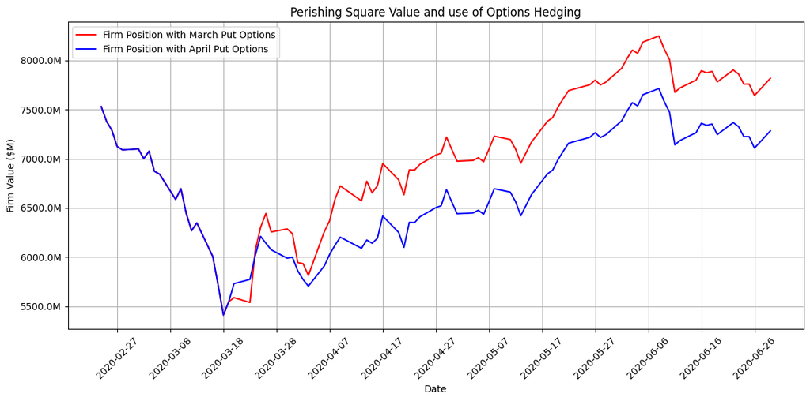

```python
plt.figure(figsize=(12, 6))
plt.plot(df_profits.index, df_profits['Value March'], linestyle='-', color='r', label='Firm Position with March Put Options')
plt.plot(df_profits.index, df_profits['Value April'], linestyle='-', color='b', label='Firm Position with April Put Options')

plt.title('Perishing Square Value and use of Options Hedging')
plt.xlabel('Date')
plt.ylabel('Firm Value ($M)')
plt.xticks(rotation=45)
plt.gca().xaxis.set_major_locator(mdates.DayLocator(interval=10))
plt.gca().yaxis.set_major_formatter(ticker.FuncFormatter(lambda x, pos: f'{x*1e-6:.1f}M'))
plt.grid()
plt.legend()
plt.tight_layout()
plt.show()
```

## 4.4 Sensitivity analysis

#### Changes in implied volatility

- The implied volatility of the options contract was determined using Newton's method. By iteratively solving the Black-Scholes model, the volatility is adjusted until the model's theoretical option price matched the observed market price. Newton's method efficiently converged to the implied volatility by minimizing the difference between the model and market prices.

However, performing a sensitivity analysis on implied volatility was not considered insightful for this analysis. Since the implied volatility is derived directly from market conditions and is used as an input in the option pricing model, further sensitivity analysis on this parameter would not provide meaningful or new information in this context.

The following code (derived from lecture materials) is a implementation of Newtons method to calculate the implied volatility of the March expiry put options contract.

```python
def black_scholes (S, K, r, T, sigma , q):
    d1 = (np.log(S / K) + (r - q + 0.5 * sigma ** 2) * T) / (sigma * np.sqrt(T)); d2 = d1 - sigma * np.sqrt(T)
    C = S * np.exp(-q * T) * norm.cdf(d1) - K * np.exp(-r * T) * norm.cdf(d2) # call
    P = -S * np.exp(-q * T) * norm.cdf(-d1) + K * np.exp(-r * T) * norm.cdf(-d2) # put
    return [C, P]

# function to calculate option vega
def vega(S, K, r, T, sigma , q):
    d1 = (np.log(S / K) + (r - q + 0.5 * sigma ** 2) * T) / ( sigma * np.sqrt(T))
    return np.exp(-q * T) * S * norm.pdf(d1) * np.sqrt(T) # same for calls and puts

# observed call or put price
obs = P_MAR # put price

# known / observed / given parameter values
S = spx_price
K = K
r = THIRTY_DAY_SOFR
T = T_MAR;
q = 0

# Newton ’s method
sigma = np.sqrt (2 * np.abs(np.log(S / (K * np.exp(-r * T))))/T) # initial guess of sigma
val = black_scholes(S, K, r, T, sigma, q)[1]

while (abs(val -obs) > 10 ** -8):
    v = vega(S, K, r, T, sigma , q)
    sigma = sigma - (val - obs)/v # Newton step to update / improve estimate of sigma
    val = black_scholes(S, K, r, T, sigma , q)[1]

print(f"Implied volatility: {sigma:.6f}")
```

```
Implied volatility: 0.190229
```

### 4.5 Acknowledgements and Tooling

This work is licensed under the MIT License and is freely available for distribution. All rights are reserved by the author, DanielCiccC.

- Various tools, including GitHub, GitHub Copilot, and ChatGPT, were utilized in the development and analysis of this project.
- Portions of the code were adapted from examples provided in lectures.

[output not shown]